# COVID19 Report

Holly Nereson

2024-04-28

## Introduction

This report offers a detailed analysis of COVID-19 data sourced from the Johns Hopkins University GitHub repository, focusing on the number of cases and deaths across various geographic locations and over different time periods. By delving into this comprehensive dataset, our objective is to explore and quantify the relationship between the incidence of COVID-19 cases and the resulting deaths. *We aim to understand if a higher number of reported cases in a region correlates with an increased number of deaths, which could provide critical insights into the deadly effect of the virus in different environments and under various conditions.* This analysis is not only pivotal for public health officials and policymakers but also for the general public as it sheds light on the dynamics of the pandemic’s impact across the globe. Through visual and statistical methods, this report will examine trends, patterns, and correlations to better understand how the virus has spread and affected populations differently.

The main question we are looking at is the relationship between the number of cases and deaths in different locations and are they correlated.

You can find the .Rmd file in this Github repo: https://github.com/grayhalls/Covid-19-data-eda/blob/master/Covid19_report.rmd

**This file uses tidyverse and lubridate, so confirm that those packages are installed on your machine before running.**

```r
library(tidyverse)
library(lubridate)

# Load the data from the URL
covid_url <- "https://raw.githubusercontent.com/CSSEGISandData/COVID-19/master/csse_covid_19_data/csse_covid_19_time_series/"

# File names
files <- c("time_series_covid19_confirmed_US.csv",
           "time_series_covid19_confirmed_global.csv",
           "time_series_covid19_deaths_US.csv",
           "time_series_covid19_deaths_global.csv")

# Function to create full URL and read data
read_covid_data <- str_c(covid_url,files)

# Importing data
confirmed_US <- read_csv(read_covid_data[1])
confirmed_global <- read_csv(read_covid_data[2])
deaths_US <- read_csv(read_covid_data[3])
deaths_global <- read_csv(read_covid_data[4])
```

### Cleaning the Data

We are tidying the data since these are 4 different datasets. We want to create 2 datasets, one for global and another for the US which can be comparable. Therefore, we are creating each dataset to have these columns: Province_State, Country_Region, date, cases, deaths, Population, and Combined_Key.

```r
# Cleaning
confirmed_global <- confirmed_global %>%
    pivot_longer(cols = -c('Province/State',
                           'Country/Region', Lat, Long),
                 names_to = "date",
                 values_to = "cases") %>%
    select(-c(Lat,Long))

deaths_global <- deaths_global %>%
  pivot_longer(cols = -c('Province/State',
                         'Country/Region', Lat, Long),
               names_to = "date",
               values_to = "deaths") %>%
  select(-c(Lat,Long))

global <- confirmed_global %>%
  full_join(deaths_global) %>%
  rename(Country_Region = 'Country/Region',
         Province_State = 'Province/State') %>%
  mutate(date = mdy(date))

confirmed_US <- confirmed_US %>%
  pivot_longer(cols = -c(UID:Combined_Key),
               names_to = "date",
               values_to = "cases") %>%
  select(Admin2:cases) %>%
  mutate(date = mdy(date)) %>%
  select(-c(Lat,Long_))

deaths_US <- deaths_US %>%
  pivot_longer(cols = -c(UID:Population),
               names_to = "date",
               values_to = "deaths") %>%
  select(Admin2:deaths) %>%
  mutate(date = mdy(date)) %>%
  select(-c(Lat,Long_))

US <- confirmed_US %>%
  full_join(deaths_US)

global <- global %>% filter(cases > 0)

global <- global %>%
  unite("Combined_Key",
        c(Province_State, Country_Region),
        sep = ", ",
        na.rm = TRUE,
        remove = FALSE)

uid_lookup_url <- "https://raw.githubusercontent.com/CSSEGISandData/COVID-19/master/csse_covid_19_data/UID_ISO_FIPS_LookUp_Table.csv"

uid <- read_csv(uid_lookup_url) %>%
  select(-c(Lat, Long_, Combined_Key, code3, iso2, iso3, Admin2))

global <- global %>%
  left_join(uid, by = c("Province_State", "Country_Region")) %>%
  select(-c(UID, FIPS)) %>%
  select(Province_State, Country_Region, date,
         cases, deaths, Population, Combined_Key)

head(global)
```

```
## # A tibble: 6 × 7
##   Province_State Country_Region date       cases deaths Population Combined_Key
##   <chr>          <chr>          <date>     <dbl>  <dbl>      <dbl> <chr>
## 1 <NA>           Afghanistan    2020-02-24     5      0   38928341 Afghanistan
## 2 <NA>           Afghanistan    2020-02-25     5      0   38928341 Afghanistan
## 3 <NA>           Afghanistan    2020-02-26     5      0   38928341 Afghanistan
## 4 <NA>           Afghanistan    2020-02-27     5      0   38928341 Afghanistan
## 5 <NA>           Afghanistan    2020-02-28     5      0   38928341 Afghanistan
## 6 <NA>           Afghanistan    2020-02-29     5      0   38928341 Afghanistan
```

```r
head(US)
```

```
## # A tibble: 6 × 8
##   Admin2  Province_State Country_Region Combined_Key date       cases Population
##   <chr>   <chr>          <chr>          <chr>        <date>     <dbl>      <dbl>
## 1 Autauga Alabama        US             Autauga, Al… 2020-01-22     0      55869
## 2 Autauga Alabama        US             Autauga, Al… 2020-01-23     0      55869
## 3 Autauga Alabama        US             Autauga, Al… 2020-01-24     0      55869
## 4 Autauga Alabama        US             Autauga, Al… 2020-01-25     0      55869
## 5 Autauga Alabama        US             Autauga, Al… 2020-01-26     0      55869
## 6 Autauga Alabama        US             Autauga, Al… 2020-01-27     0      55869
## # ℹ 1 more variable: deaths <dbl>
```

### Visualizing Data

In this section, we examine the progression of COVID-19 cases and deaths over time across the United States and specifically in Colorado. We utilize data that tracks the number of cases and fatalities, converting these figures to rates per million to standardize across varying population sizes. Through detailed visualizations, we aim to uncover patterns and trends in the spread of the virus and its lethal impact. These visuals will help us better understand how the virus has affected different regions over time and provide a clear depiction of the relationship between case rates and death rates.

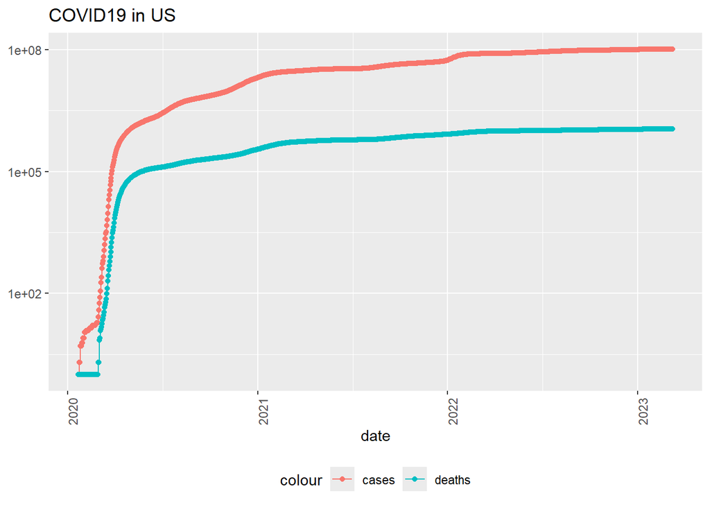

```r
US_by_state <- US %>%
  group_by(Province_State, Country_Region, date) %>%
  summarize(cases = sum(cases), deaths = sum(deaths),
            Population = sum(Population)) %>%
  mutate(deaths_per_mill = deaths *1000000 / Population) %>%
  select(Province_State, Country_Region, date, cases, deaths, deaths_per_mill, Population) %>%
  ungroup()

US_totals <- US_by_state %>%
  group_by(Country_Region, date) %>%
  summarize(cases = sum(cases), deaths = sum(deaths),
            Population = sum(Population)) %>%
  mutate(deaths_per_mill = deaths *1000000 / Population) %>%
  select(Country_Region, date, cases, deaths, deaths_per_mill, Population) %>%
  ungroup()

# plot of us cases and deaths over time
US_totals %>%
  filter(cases > 0) %>%
  ggplot(aes(x = date, y = cases)) +
  geom_line(aes(color = "cases")) +
  geom_point(aes(color = "cases")) +
  geom_line(aes(y = deaths, color = "deaths")) +
  geom_point(aes(y = deaths, color = "deaths")) +
  scale_y_log10() +
  theme(legend.position="bottom",
        axis.text.x = element_text(angle = 90)) +
  labs(title = "COVID19 in US", y= NULL)
```

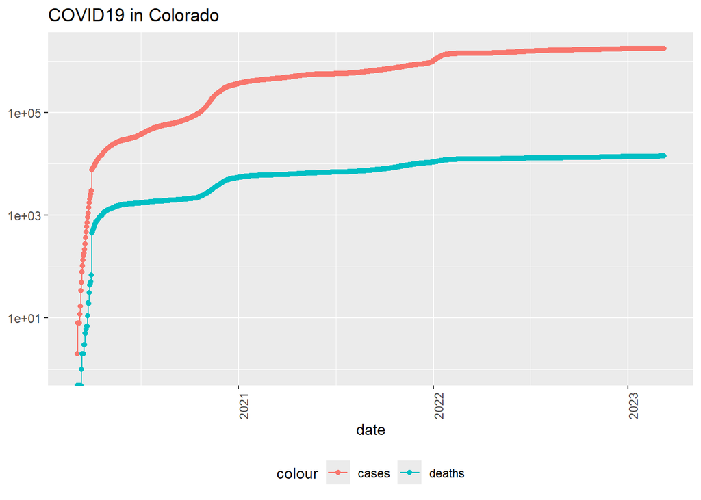

```r
# plot of NY cases and deaths over time
state <- "Colorado"
US_by_state %>%
  filter(Province_State == state) %>%
  filter(cases > 0) %>%
  ggplot(aes(x = date, y = cases)) +
  geom_line(aes(color = "cases")) +
  geom_point(aes(color = "cases")) +
  geom_line(aes(y = deaths, color = "deaths")) +
  geom_point(aes(y = deaths, color = "deaths")) +
  scale_y_log10() +
  theme(legend.position="bottom",
        axis.text.x = element_text(angle = 90)) +
  labs(title = str_c("COVID19 in ", state), y= NULL)
```

```r
US_by_state <- US_by_state %>%
  group_by(Province_State) %>%
  mutate(new_cases = cases - lag(cases),
         new_deaths = deaths - lag(deaths)) %>%
  ungroup()

US_totals <- US_totals %>%
  group_by(Country_Region) %>%
  mutate(new_cases = cases - lag(cases),
         new_deaths = deaths - lag(deaths)) %>%
  ungroup()
```

Next, we want to look at the number of new cases and new deaths by day in both the US and Colorado. These will be plotted on a log scale to better see patterns. We also look at a heatmap showing how death rates varied over time across different states. The color intensity represents the magnitude of deaths.

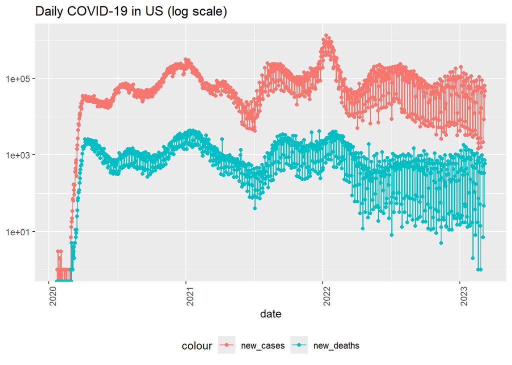

```r
US_totals %>%
  ggplot(aes(x = date, y = new_cases)) +
  geom_line(aes(color = "new_cases")) +
  geom_point(aes(color = "new_cases")) +
  geom_line(aes(y = new_deaths, color = "new_deaths")) +
  geom_point(aes(y = new_deaths, color = "new_deaths")) +
  scale_y_log10() +
  theme(legend.position="bottom",
        axis.text.x = element_text(angle = 90)) +
  labs(title = "Daily COVID-19 in US (log scale)", y= NULL)
```

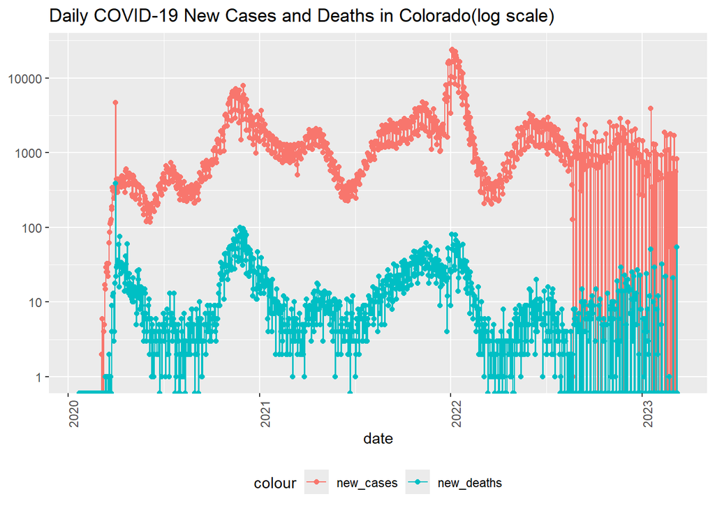

```r
US_by_state %>%
  filter(Province_State == state) %>%
  ggplot(aes(x = date, y = new_cases)) +
  geom_line(aes(color = "new_cases")) +
  geom_point(aes(color = "new_cases")) +
  geom_line(aes(y = new_deaths, color = "new_deaths")) +
  geom_point(aes(y = new_deaths, color = "new_deaths")) +
  scale_y_log10() +
  theme(legend.position="bottom",
        axis.text.x = element_text(angle = 90)) +
  labs(title = str_c("Daily COVID-19 New Cases and Deaths in ", state, "(log scale)"), y = NULL)
```

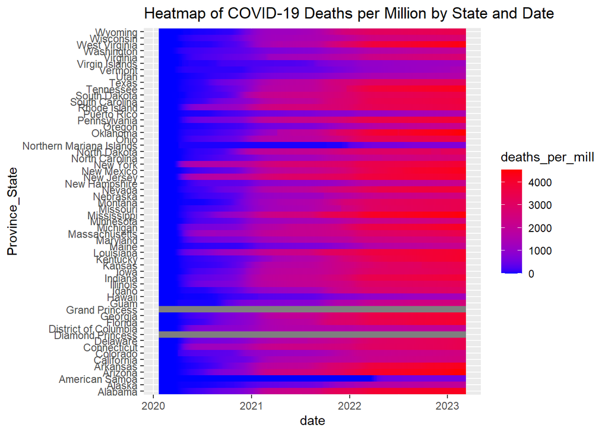

```r
ggplot(US_by_state, aes(x = date, y = Province_State, fill = deaths_per_mill)) +
    geom_tile() +
    scale_fill_gradient(low = "blue", high = "red") +
    labs(title = "Heatmap of COVID-19 Deaths per Million by State and Date")
```

```r
US_state_totals <- US_by_state %>%
  group_by(Province_State) %>%
  summarize(deaths = max(deaths), cases = max(cases),
            population = max(Population),
            cases_per_thou = 1000 * cases / population,
            deaths_per_thou = 1000 * deaths / population) %>%
  filter(cases > 0, population > 0)

US_state_totals %>%
  slice_min(deaths_per_thou, n=10)
```

```
## # A tibble: 10 × 6
##    Province_State        deaths  cases population cases_per_thou deaths_per_thou
##    <chr>                  <dbl>  <dbl>      <dbl>          <dbl>           <dbl>
##  1 American Samoa            34 8.32e3      55641           150.           0.611
##  2 Northern Mariana Isl…     41 1.37e4      55144           248.           0.744
##  3 Virgin Islands           130 2.48e4     107268           231.           1.21
##  4 Hawaii                  1841 3.81e5    1415872           269.           1.30
##  5 Vermont                  929 1.53e5     623989           245.           1.49
##  6 Puerto Rico             5823 1.10e6    3754939           293.           1.55
##  7 Utah                    5298 1.09e6    3205958           340.           1.65
##  8 Alaska                  1486 3.08e5     740995           415.           2.01
##  9 District of Columbia    1432 1.78e5     705749           252.           2.03
## 10 Washington             15683 1.93e6    7614893           253.           2.06
```

```r
head(US_state_totals)
```

```
## # A tibble: 6 × 6
##   Province_State deaths    cases population cases_per_thou deaths_per_thou
##   <chr>           <dbl>    <dbl>      <dbl>          <dbl>           <dbl>
## 1 Alabama         21032  1644533    4903185           335.           4.29
## 2 Alaska           1486   307655     740995           415.           2.01
## 3 American Samoa     34     8320      55641           150.           0.611
## 4 Arizona         33102  2443514    7278717           336.           4.55
## 5 Arkansas        13020  1006883    3017804           334.           4.31
## 6 California     101159 12129699   39512223           307.           2.56
```

### Modeling the Data

All of the previous visuals indicate a correlation between number of cases and number of deaths, both in the US at large and in Colorado. Therefore, we want to test that correlation statistically to see if the number of cases is predictive of the number of deaths. To do this, we will set up a simple linear regression using the US_state_totals dataframe, which you can see above. We will use cases_per_thou and deaths_per_thou.

We attempted to include population as a factor, but it has a high p-value indicating that population was not statistically significant.

```r
mod <- lm(deaths_per_thou ~ cases_per_thou, data = US_state_totals)
summary(mod)
```

```
##
## Call:
## lm(formula = deaths_per_thou ~ cases_per_thou, data = US_state_totals)
##
## Residuals:
##     Min      1Q  Median      3Q     Max
## -2.3352 -0.5978  0.1491  0.6535  1.2086
##
## Coefficients:
##                Estimate Std. Error t value Pr(>|t|)
## (Intercept)    -0.36167    0.72480  -0.499     0.62
## cases_per_thou  0.01133    0.00232   4.881 9.76e-06 ***
## ---
## Signif. codes:  0 '***' 0.001 '**' 0.01 '*' 0.05 '.' 0.1 ' ' 1
##
## Residual standard error: 0.8615 on 54 degrees of freedom
## Multiple R-squared:  0.3061, Adjusted R-squared:  0.2933
## F-statistic: 23.82 on 1 and 54 DF,  p-value: 9.763e-06
```

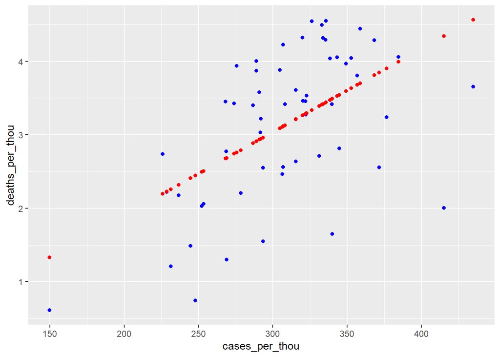

```r
US_tot_w_pred <- US_state_totals %>% mutate(pred = predict(mod))

US_tot_w_pred %>% ggplot() +
  geom_point(aes(x = cases_per_thou, y = deaths_per_thou), color = "blue") +
  geom_point(aes(x = cases_per_thou, y = pred), color = "red")
```

### Conclusion

Our linear model shows a statistically significant relationship between the total number of cases per thousand people and the number of deaths per thousand people.The multiple R-squared value is `0.3061` which indicates that approximately 30.61% of the variability in deaths per thousand is explained by the model. With a p-value of `9.763e-06`, the model most likely is statistically significant.

The coefficient for cases_per_thou is `0.01133`, with a standard error of `0.00232`. This coefficient is statistically significant (p-value = `9.76e-06`), indicating a positive relationship between the number of cases and the number of deaths. For every additional case per thousand people, there is an increase of about `0.01133` deaths per thousand people.

From the graph, we can observe that generally the trend of deaths_per_thou increases as cases_per_thou increases. However, there is significant variability among the states.

### Potential Areas of Bias

Several potential areas of bias can be influencing the results.

- **Reporting Inconsistencies:** This data relies heavily on the reliability in reporting among various testing sites and healthcare providers and across states. The timing of reporting could be delayed leading to a lag in the results.
- **Confounding Variables:** This model is very simple, only including cases per thousand and deaths per thousand. However, there are many other factors that could be influencing death rates, such as access to healthcare, population density, public health policies, etc.
- **Socioeconomic Factors:** Income level, access to healthcare, and employment types are not accounted for, but could significantly influence the spread of the virus and mortality rate.